# Agency Analysis

Sales Analysis and Forecasts

Zoe Chow

April 15, 2025

## 1 Introduction

This report analyzes the performance of sales agencies, their agents, and provides statistically derived forecasts for future sales. The data was extracted from the database hosted on Aiven as well as agent-related data provided by marketing in the form of an XML file. The database contains sales transactions for `99` homes for the years `2017` through `2024`. For each sale, we have records of `7` distinct characteristics of the home, such as whether the home has a pool, what kind of air condition is featured in the home, and the amount of land.

## 2 Sales Analysis

### 2.1 Analysis of Sales by Agency

We employ `8` agents across `4` agencies. The list of agencies in their aggregate sales for the most recent three years (`2022` to `2024`) are shown in the table below, in no particular order.

TABLE 1: Total of sale prices in thousands US$.

| Agency | 2022 | 2023 | 2024 | Avg | Total Sold |
| --- | --- | --- | --- | --- | --- |
| Golden Coast Realty | 316,710 | ** | 545,292 | 287,334 | 862,002 |
| Oceanview Properties | 1,942,672 | 2,222,478 | 2,712,690 | 2,292,613 | 6,877,840 |
| Palm Tree Realty | 1,025,590 | 2,163,267 | 2,225,232 | 1,804,696 | 5,414,089 |
| Sunshine Realty | 963,900 | 691,254 | 950,130 | 868,428 | 2,605,284 |
| Total | 4,248,872 | 5,076,999 | 6,433,344 | ** | 15,759,215 |

`Oceanview Properties` had the most sales for the most recent year, while `Oceanview Properties` has the most overall sales.

### 2.2 Analyis of Sales by Agent

We have `8` agents selling homes for years from `2017` to `2024`. `Brian Anderson` is currently first on the leaderboard for having the most sales revenue of `$6,900,424` (the total of the sales prices), while `Brian Anderson` has the most sales by unit (`21`). Based on commission earned, `Emily Carter` of `Oceanview Properties` in `Boca Raton` has earned the most commission since they joined us. For the most recent year, a total of `$23,589,387` was earned in commission by our sales agents which represents an `increase` of `31.64%` over the prior year’s total of `$17,919,314`. The average sales commission in the most recent year was `$2,948,673`.

TABLE 2: Sales by Agent (in Thousands US$).

| Agent | 2024 | 2023 | Avg | Total Sold |
| --- | --- | --- | --- | --- |
| Amanda Scott | 1,140,156 | 740,826 | 940,491 | 1,880,982 |
| Brian Anderson | 1,085,076 | 1,422,441 | 1,253,758 | 2,507,517 |
| David Lopez | 685,746 | 380,052 | 532,899 | 1,065,798 |
| Emily Carter | 955,638 | 839,970 | 897,804 | 1,795,608 |
| Jessica Rivera | 550,800 | 366,282 | 458,541 | 917,082 |
| Kevin Mitchell | 545,292 | ** | 545,292 | 545,292 |
| Michael Thompson | 399,330 | 324,972 | 362,151 | 724,302 |
| Sarah Collins | 1,071,306 | 1,002,456 | 1,036,881 | 2,073,762 |

## 3 Forecasting

There is an increasing need for more accurate forecasts of revenue per agency as well as overall across agencies. The chart below shows the trend over the total monthly sales for the past year. We are showing an interpolated regression line.

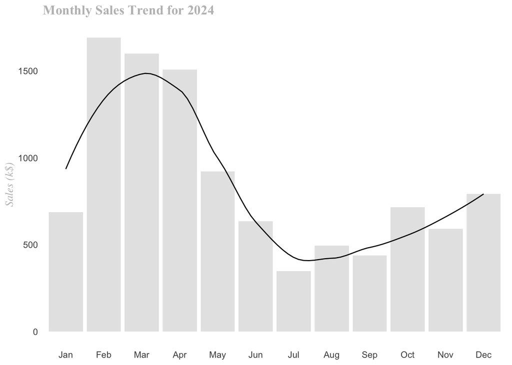

We used a weighted moving average of the prior four months sales with weights of 0.7 for the most recent months and equal weights for the remaining months to estimate total sales for next two months to be `$727,469.10` and `$718,807.77`.

## 4 Home Pricing Model

To assist agents in setting a price that is market-oriented and fair, we have built a pricing equation that can estimate the likely sales price of a property based on its key characteristics. Pricing of a property should be the estimated price adjusted by a markup to account for sales commission and profit.

The pricing model was developed using multiple linear regression and an estimate for the likely selling price of a home based on various characteristics can be calculated with the equation below:
$$estimate = -3.667e^7 + 1.825e^4(y) +1.108e^2(l)
+ 4.442e^4(s) + 1.546e^5(p) + 2.75e^5(c)$$
where,

- $y$ = year
- $l$ = land size in square meters
- $s$ = number of parking spots available
- $p$ = presence of a pool (1 = present, 0 = absent)
- $c$ = presence of central AC (1 = present, 0 = absent)

As an aside, we have recently embedded the equation into the “Estimator” calculator on our website, so that our clients have an idea of a likely selling price based on comparables. To demonstrate the usefulness of the updated pricing model, we demonstrate the calculation of the estimated selling price of a 32-year-old four-bedroom single-family home on a 518$\text{m}^2$ lot, with an in-ground pool, no presence of UFFI, central AC, a two-car garage, and having a finished basement with a media room and a gym. For this home, the pricing model estimates a selling price between `$655,426.95` and `$829,948.74` (the 95% confidence interval).

It is interesting to note that homes that have UFFI (Urea Formaldehyde Foam Insulation), a type of insulation that was popular in the 1970s and 1980s, but is now recognized as problematic due to formaldehyde off-gassing and other issues, have, on average, a `10.96%` lower sales price, however this difference in price `does not` seem to be statistically significant (t = `1.319`, p = `0.195`) despite claims to the contrary by the Realtor Association.

## 7 References

[ChatGPT conversation](https://chatgpt.com/share/67fd8cac-de00-800b-8d84-5486f0769f28)  
[6.301 Woking with Databases in R](http://artificium.us/lessons/06.r/l-6-301-sqlite-from-r/l-6-301.html)  
[6.323 Load Simple XML into Dataframe in R using xmlToDataFrame()](http://artificium.us/lessons/06.r/l-6-323-load-xml-xmlToDataFrame/l-6-323.html)  
6.107 Data Manipulation with dpylr  
[6.113 Working wiht Date and Time Values in R](http://artificium.us/lessons/06.r/l-6-113-date-time-in-r/l-6-113.html)  
[3.203 Detecting and Managing Outliers](http://artificium.us/lessons/03.ml/l-3-203-outliers/l-3-203.html#Handling_Outliers)  
[60.101 Tabular Structures, Relational Data, and SQL](http://artificium.us/lessons/60.dbdesign/l-60-101-tabular-reldb-sql/l-60-101.html#Introduction) [3.303 Basic Time Series Forecasting](http://artificium.us/lessons/03.ml/l-3-303-time-series-forecasting-r/l-3-303.html#Lecture:_Trend_Line)  
[3.409 kNN for Classification: A Primer](http://artificium.us/lessons/03.ml/l-3-409-knn-primer/l-3-409.html#Objectives)  
[3.440 Multiple Regression: A Primer](http://artificium.us/lessons/03.ml/l-3-440-primer-regression/l-3-440.html#Introduction)  
[Create Awesome HTML Table with knitr::kable and kableExtra](https://cran.r-project.org/web/packages/kableExtra/vignettes/awesome_table_in_html.html#Overview)  
[Introduction to ggplot2](https://ggplot2.tidyverse.org/articles/ggplot2.html#theme)